# Automatic cell type assignment in scRNA-seq data

Charlotte Soneson

2019-10-16

# Introduction

In this document we will illustrate the use of several automatic cell type annotation packages. We will use an example data set consisting of 2,700 PBMCs, sequenced using 10x Genomics technology.

# Load packages

We first load the required R packages.

```r
suppressPackageStartupMessages({
  library(SummarizedExperiment)
  library(SingleCellExperiment)
  library(TENxPBMCData)
  library(scater)
  library(scran)
  library(BiocSingular)
  library(pheatmap)
  library(Seurat)
  library(igraph)
  library(ggplot2)
  library(limma)
  library(edgeR)
  library(cellassign)
  library(SingleR)
  library(AUCell)
})
```

# Load and preprocess data

```r
## Load data
sce <- TENxPBMCData::TENxPBMCData(dataset = "pbmc3k")
```

```
## snapshotDate(): 2019-09-25
```

```
## see ?TENxPBMCData and browseVignettes('TENxPBMCData') for documentation
```

```
## downloading 0 resources
```

```
## loading from cache
```

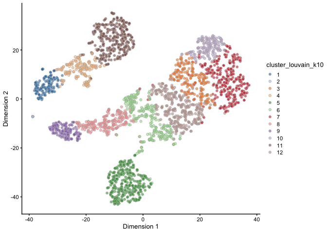

```r
## Add column names, and use gene symbol as row names wherever possible
colnames(sce) <- paste0("Cell", seq_len(ncol(sce)))
rownames(sce) <- scater::uniquifyFeatureNames(
    ID = rowData(sce)$ENSEMBL_ID,
    names = rowData(sce)$Symbol_TENx
)
sce$cell <- colnames(sce)

## Calculate QC metrics and remove cells with more than 5% reads from
## mitochondrial genes
MT <- rownames(sce)[grep("^MT-", rownames(sce))]
df <- scater::perCellQCMetrics(
  x = sce,
  subsets = list(MT = MT)
)
colData(sce) <- cbind(colData(sce), df)
sce <- sce[, sce$subsets_MT_percent < 5]

## Calculate size factors and normalize
## Note that the pre-clustering step has been excluded to save computational
## time
sce <- scran::computeSumFactors(sce, min.mean = 0.1)
sce <- scater::logNormCounts(sce)
logcounts(sce) <- as.matrix(logcounts(sce))

## Fit variance trend and apply denoising PCA
dec <- scran::modelGeneVar(sce)
set.seed(123)
sce <- scran::denoisePCA(sce, technical = dec, BSPARAM = IrlbaParam())

## Apply tSNE
set.seed(123)
sce <- scater::runTSNE(sce, dimred = "PCA", perplexity = 30)

## Cluster
graph_k10 <- scran::buildSNNGraph(sce, k = 10, use.dimred = "PCA", type = "rank")
clust_k10_louvain <- igraph::cluster_louvain(graph_k10)$membership
sce$cluster_louvain_k10 <- factor(clust_k10_louvain)
scater::plotReducedDim(sce, "TSNE", colour_by = "cluster_louvain_k10")
```

```r
sce <- sce[, 1:750]
```

# CellAssign

CellAssign (Zhang et al. 2019) takes as input a single-cell data set (as a `SingleCellExperiment` object) and a collection of marker genes for cell types of interest. The method builds on the assumption that a cell from a certain cell type should display a high expression of the marker genes for that cell type. For illustration, here we are using a set of marker genes for cell types in a tumour microenvironment, provided with the `CellAssign` package.

```r
## Load the marker genes and convert to binary indicator matrix
data(example_TME_markers)
(marker_gene_mat <- marker_list_to_mat(example_TME_markers$symbol))
```

```
##          B cells T cells Cytotoxic T cells Monocyte/Macrophage
## ACTA2          0       0                 0                   0
## CD14           0       0                 0                   1
## CD19           1       0                 0                   0
## CD2            0       1                 1                   0
## CD24           1       0                 0                   0
## CD28           0       1                 1                   0
## CD33           0       0                 0                   1
## CD3D           0       1                 1                   0
## CD3E           0       1                 1                   0
## CD3G           0       1                 1                   0
## CD4            0       1                 0                   1
## CD79A          1       0                 0                   0
## CD8A           0       0                 1                   0
## CDH1           0       0                 0                   0
## CDH5           0       0                 0                   0
## CLDN3          0       0                 0                   0
## CLDN4          0       0                 0                   0
## CLEC14A        0       0                 0                   0
## COL1A1         0       0                 0                   0
## COL3A1         0       0                 0                   0
## EMCN           0       0                 0                   0
## EPCAM          0       0                 0                   0
## FCGR3A         0       0                 0                   1
## GZMA           0       0                 1                   0
## ITGAM          0       0                 0                   1
## ITGAX          0       0                 0                   1
## LYZ            0       0                 0                   1
## MCAM           0       0                 0                   0
## MS4A1          1       0                 0                   0
## MYH11          0       0                 0                   0
## MYLK           0       0                 0                   0
## NKG7           0       0                 1                   0
## PECAM1         0       0                 0                   0
## PLN            0       0                 0                   0
## PRF1           0       0                 1                   0
## PTPRC          1       1                 1                   1
## SERPINH1       0       0                 0                   0
## VIM            1       1                 1                   1
## VWF            0       0                 0                   0
```

[output cut: 65 more lines]

```
## ITGAM                    0     0
## ITGAX                    0     0
## LYZ                      0     0
## MCAM                     1     0
## MS4A1                    0     0
## MYH11                    0     0
## MYLK                     0     0
## NKG7                     0     0
## PECAM1                   1     0
## PLN                      0     0
## PRF1                     0     0
## PTPRC                    0     0
## SERPINH1                 1     0
## VIM                      1     0
## VWF                      1     0
```

```r
## Find markers shared with the data set
shared <- intersect(rownames(marker_gene_mat), rownames(sce))
s <- sizeFactors(sce)

## Run cellassign. The data set should be subset to the marker genes
fit <- cellassign(exprs_obj = sce[shared, ],
                  marker_gene_info = marker_gene_mat[shared, ],
                  s = s,
                  learning_rate = 1e-2,
                  shrinkage = TRUE,
                  verbose = FALSE)
## Predicted cell types and posterior probabilities
print(head(celltypes(fit)))
```

```
## [1] "Cytotoxic T cells"   "B cells"             "Cytotoxic T cells"
## [4] "Monocyte/Macrophage" "Cytotoxic T cells"   "Cytotoxic T cells"
```

```r
print(head(cellprobs(fit)))
```

```
##           B cells      T cells Cytotoxic T cells Monocyte/Macrophage
## [1,] 5.682052e-06 2.459347e-14      9.999916e-01        2.662367e-06
## [2,] 9.999999e-01 9.120164e-21      3.043269e-08        3.642928e-08
## [3,] 3.546612e-11 8.718447e-13      1.000000e+00        1.156666e-11
## [4,] 1.595091e-06 1.574999e-18      1.262782e-05        9.999855e-01
## [5,] 2.060520e-10 4.386193e-23      1.000000e+00        2.301922e-11
## [6,] 8.537414e-04 4.776439e-13      9.979890e-01        1.152145e-03
##      Epithelial cells Myofibroblast Vascular smooth muscle cells
## [1,]     7.628969e-12  1.225058e-11                 6.193463e-12
## [2,]     6.350016e-15  1.889068e-13                 7.942218e-14
## [3,]     5.034158e-17  6.953427e-17                 3.054440e-17
## [4,]     1.972433e-11  5.421507e-12                 2.548232e-12
## [5,]     6.984863e-16  1.023776e-16                 5.573620e-17
## [6,]     3.983346e-10  2.236500e-08                 1.125137e-08
##      Endothelial cells        other
## [1,]      1.373205e-11 9.651955e-08
## [2,]      2.344012e-13 8.973982e-11
## [3,]      8.437968e-17 6.926728e-13
## [4,]      6.342749e-12 2.605581e-07
## [5,]      1.094129e-16 8.465151e-12
## [6,]      2.514499e-08 5.054143e-06
```

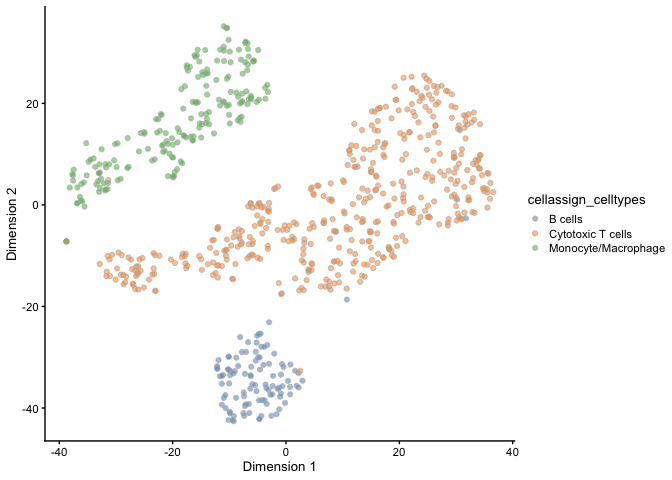

```r
## Add predicted cell types and maximal probability to SCE object
sce$cellassign_celltypes <- celltypes(fit)
sce$cellassign_maxprob <- apply(cellprobs(fit), 1, max)

## Show in tSNE
plotTSNE(sce, colour_by = "cellassign_celltypes")
```

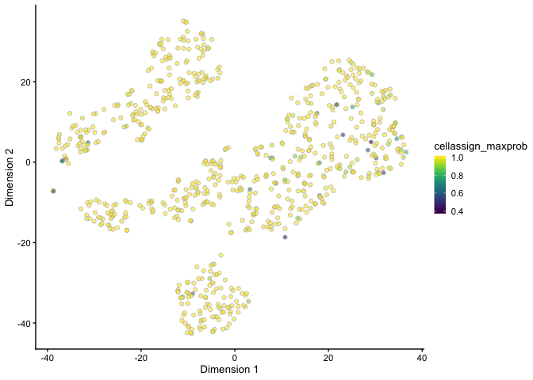

```r
plotTSNE(sce, colour_by = "cellassign_maxprob")
```

# SingleR

```r
ref <- DatabaseImmuneCellExpressionData()
```

```
## snapshotDate(): 2019-09-25
```

```
## see ?SingleR and browseVignettes('SingleR') for documentation
```

```
## downloading 0 resources
```

```
## loading from cache
```

```
## see ?SingleR and browseVignettes('SingleR') for documentation
```

```
## downloading 0 resources
```

```
## loading from cache
```

```r
ref2 <- BlueprintEncodeData()
```

```
## snapshotDate(): 2019-09-25
```

```
## see ?SingleR and browseVignettes('SingleR') for documentation
```

```
## downloading 0 resources
```

```
## loading from cache
```

```
## see ?SingleR and browseVignettes('SingleR') for documentation
```

```
## downloading 0 resources
```

```
## loading from cache
```

```r
ref3 <- HumanPrimaryCellAtlasData()
```

```
## snapshotDate(): 2019-09-25
```

```
## see ?SingleR and browseVignettes('SingleR') for documentation
```

```
## downloading 0 resources
```

```
## loading from cache
```

```
## see ?SingleR and browseVignettes('SingleR') for documentation
```

```
## downloading 0 resources
```

```
## loading from cache
```

```r
pred.sce <- SingleR::SingleR(test = sce, ref = ref, labels = ref$label.main)
pred.sce2 <- SingleR::SingleR(test = sce, ref = ref2, labels = ref2$label.main)
pred.sce3 <- SingleR::SingleR(test = sce, ref = ref3, labels = ref3$label.main)

table(pred.sce$pruned.labels, pred.sce2$pruned.labels)
```

```
##
##                 B-cells CD4+ T-cells CD8+ T-cells HSC Monocytes NK cells
##   B cells            98            0            0   0         0        0
##   Monocytes           0            0            0   0       188        0
##   NK cells            0            0           38   0         0       56
##   T cells, CD4+       0          133          132   0         0        0
##   T cells, CD8+       0           14           73   0         0        0
```

```r
table(pred.sce$pruned.labels, pred.sce3$pruned.labels)
```

```
##
##                 B_cell CMP Monocyte NK_cell Platelets Pre-B_cell_CD34-
##   B cells           98   0        0       0         0                0
##   Monocytes          0   0      182       0         0                6
##   NK cells           0   0        0      53         0                1
##   T cells, CD4+      0   0        0       0         0                0
##   T cells, CD8+      0   0        0       0         0                0
##
##                 T_cells
##   B cells             0
##   Monocytes           0
##   NK cells           39
##   T cells, CD4+     268
##   T cells, CD8+      89
```

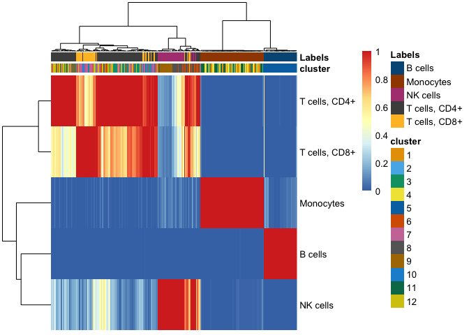

```r
sce$singleR_celltypes_dice <- pred.sce$pruned.labels
sce$singleR_celltypes_blueprint <- pred.sce2$pruned.labels
sce$singleR_celltypes_hpca <- pred.sce3$pruned.labels

SingleR::plotScoreHeatmap(
  pred.sce, show.labels = TRUE,
  annotation_col = data.frame(cluster = sce$cluster_louvain_k10,
                              row.names = rownames(pred.sce))
)
```

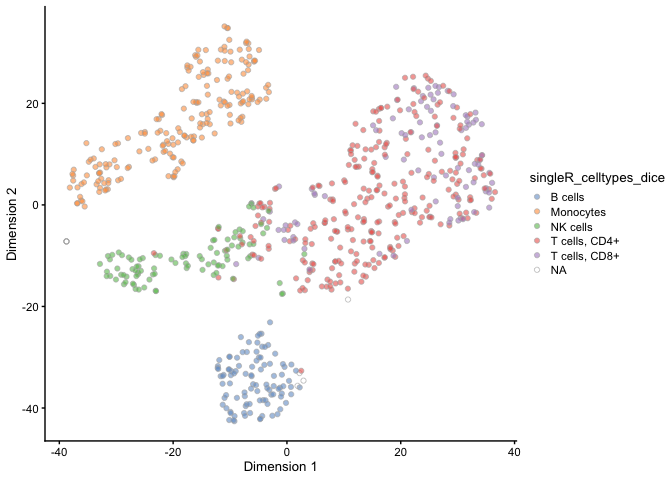

```r
scater::plotTSNE(sce, colour_by = "singleR_celltypes_dice")
```

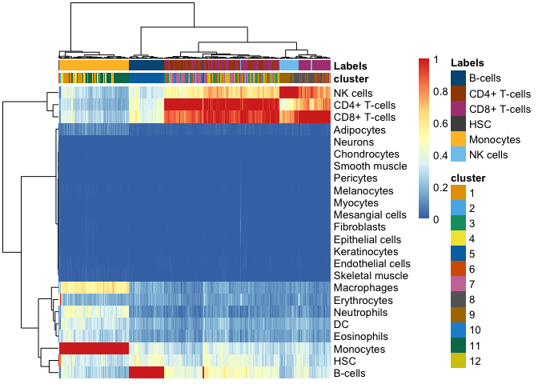

```r
SingleR::plotScoreHeatmap(
  pred.sce2, show.labels = TRUE,
  annotation_col = data.frame(cluster = sce$cluster_louvain_k10,
                              row.names = rownames(pred.sce2))
)
```

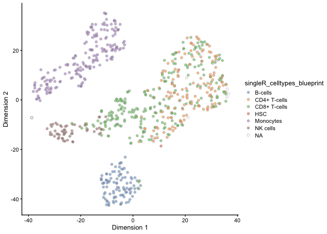

```r
scater::plotTSNE(sce, colour_by = "singleR_celltypes_blueprint")
```

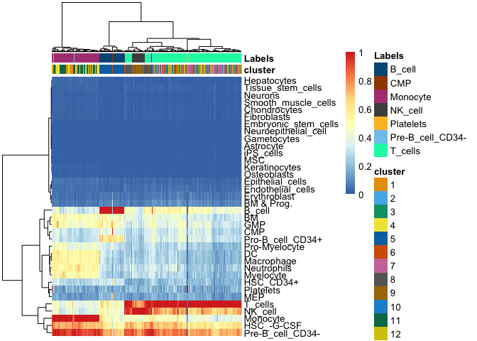

```r
SingleR::plotScoreHeatmap(
  pred.sce3, show.labels = TRUE,
  annotation_col = data.frame(cluster = sce$cluster_louvain_k10,
                              row.names = rownames(pred.sce3))
)
```

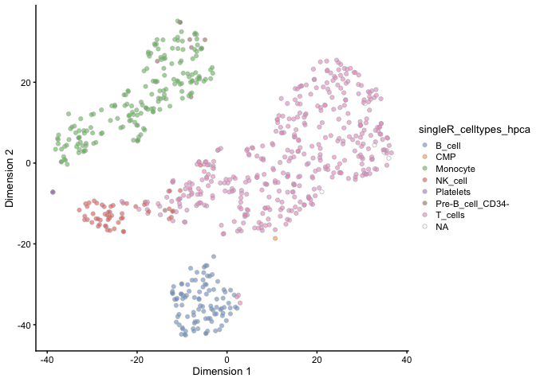

```r
scater::plotTSNE(sce, colour_by = "singleR_celltypes_hpca")
```

# AUCell

*AUCell* (Aibar et al. 2017) calculates “activation scores” for gene sets (which could, for example, consist of marker genes for specific cell types). An important difference to the previous methods is that a cell can be “assigned” to multiple reference gene sets, and not all cells are “assigned” to any reference gene set. To obtain gene sets for assigning cells to cell types, we perform pairwise t-tests on one of the reference data sets from `SingleR`, and use *scran* to extract only marker genes that are upregulated in one cell type compared to all the others.

```r
## Get some marker genes
ref <- as(DatabaseImmuneCellExpressionData(), "SingleCellExperiment")
```

```
## snapshotDate(): 2019-09-25
```

```
## see ?SingleR and browseVignettes('SingleR') for documentation
```

```
## downloading 0 resources
```

```
## loading from cache
```

```
## see ?SingleR and browseVignettes('SingleR') for documentation
```

```
## downloading 0 resources
```

```
## loading from cache
```

```r
markers <- scran::findMarkers(ref, groups = ref$label.main,
                              test.type = "t", assay.type = "logcounts",
                              lfc = 1, pval.type = "all", direction = "up")
markerlist <- lapply(markers, function(w) rownames(w)[w$FDR <= 0.01])
sapply(markerlist, length)
```

```
##       B cells     Monocytes      NK cells T cells, CD4+ T cells, CD8+
##          1058           984           680            83           101
```

```r
## Get rankings of genes in each cell
set.seed(123)
cell_rankings <- AUCell::AUCell_buildRankings(logcounts(sce), nCores = 2)
```

```
## Quantiles for the number of genes detected by cell:
## (Non-detected genes are shuffled at the end of the ranking. Keep it in mind when choosing the threshold for calculating the AUC).
```

```
##     min      1%      5%     10%     50%    100%
##  246.00  346.98  461.25  542.00  820.00 2815.00
```

```
## Using 2 cores.
```

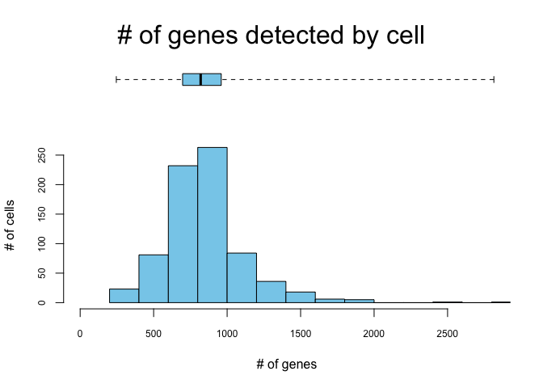

```r
## Calculate AUC for each gene set and cell
cell_AUC <- AUCell::AUCell_calcAUC(markerlist, cell_rankings,
                                   aucMaxRank = nrow(cell_rankings) * 0.05)
```

```
## Genes in the gene sets NOT available in the dataset:
##  B cells:    332 (31% of 1058)
##  Monocytes:  97 (10% of 984)
##  NK cells:   104 (15% of 680)
##  T cells, CD4+:  12 (14% of 83)
##  T cells, CD8+:  15 (15% of 101)
```

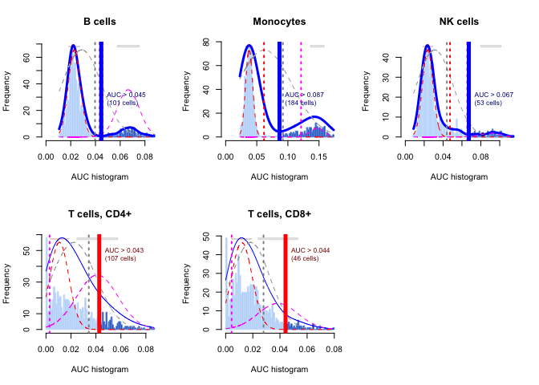

```r
## Plots for threshold selection
par(mfrow = c(2, 3))
set.seed(123)
cell_assignment <- AUCell::AUCell_exploreThresholds(
  cell_AUC, plotHist = TRUE,
  nCores = 1, assignCells = TRUE
)
```

```r
## Get assigned cells
cellsAssigned <- lapply(cell_assignment, function(x) x$assignment)
assignmentTable <- reshape2::melt(cellsAssigned, value.name = "cell")
colnames(assignmentTable)[2] <- "geneSet"
head(assignmentTable)
```

```
##     cell geneSet
## 1  Cell2 B cells
## 2 Cell11 B cells
## 3 Cell21 B cells
## 4 Cell22 B cells
## 5 Cell23 B cells
## 6 Cell26 B cells
```

```r
assignmentMat <- table(assignmentTable[, "geneSet"], assignmentTable[, "cell"])
assignmentMat[, 1:2]
```

```
##
##                 Cell109 Cell11
##   B cells             1      1
##   Monocytes           0      0
##   NK cells            0      0
##   T cells, CD4+       0      0
##   T cells, CD8+       0      0
```

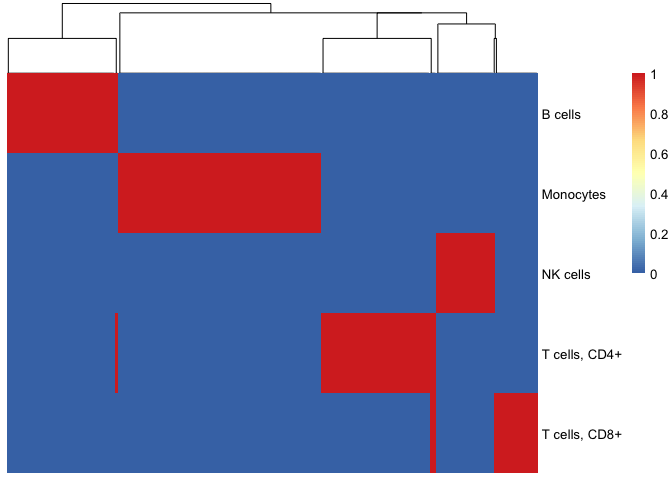

```r
set.seed(123)
miniAssigMat <- assignmentMat[, sample(1:ncol(assignmentMat), min(500, ncol(assignmentMat)))]
pheatmap(miniAssigMat, cluster_rows = FALSE, show_colnames = FALSE)
```

```r
assignments <- assignmentTable %>% dplyr::group_by(cell) %>%
  dplyr::summarize(AUCellType = paste(geneSet, collapse = "/")) %>%
  dplyr::group_by(AUCellType) %>%
  dplyr::mutate(n = length(unique(cell))) %>%
  dplyr::filter(n > 5)
sce$AUCell_celltypes <- assignments$AUCellType[match(sce$cell, assignments$cell)]
```

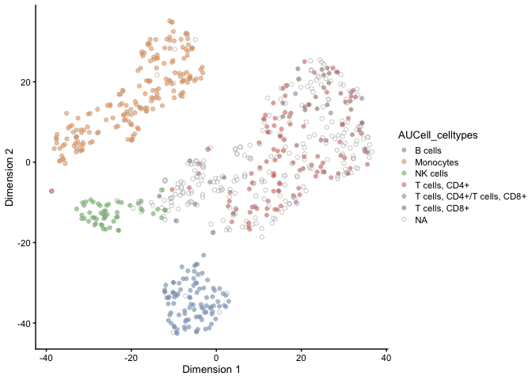

```r
plotTSNE(sce, colour_by = "AUCell_celltypes")
```

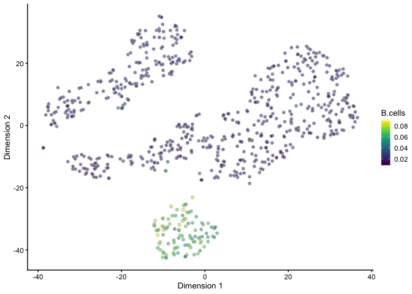

```r
colData(sce) <- cbind(colData(sce), DataFrame(t(assay(cell_AUC, "AUC"))))
plotTSNE(sce, colour_by = "B.cells")
```

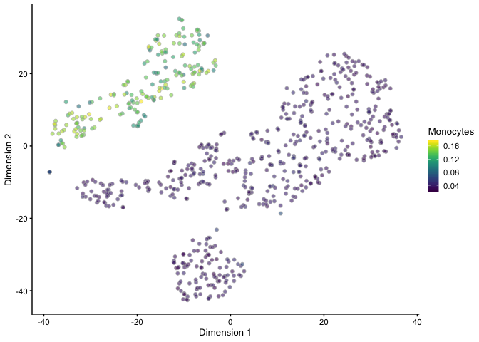

```r
plotTSNE(sce, colour_by = "Monocytes")
```

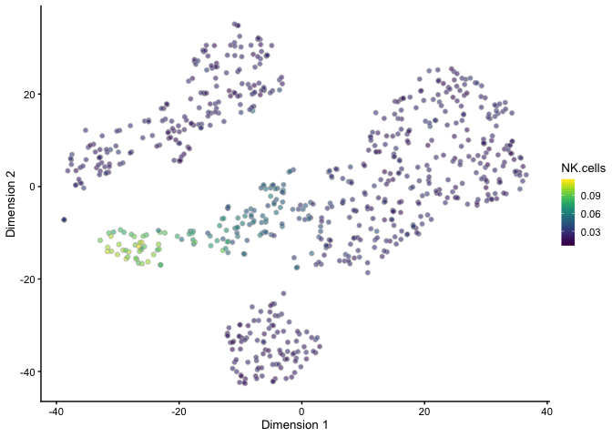

```r
plotTSNE(sce, colour_by = "NK.cells")
```

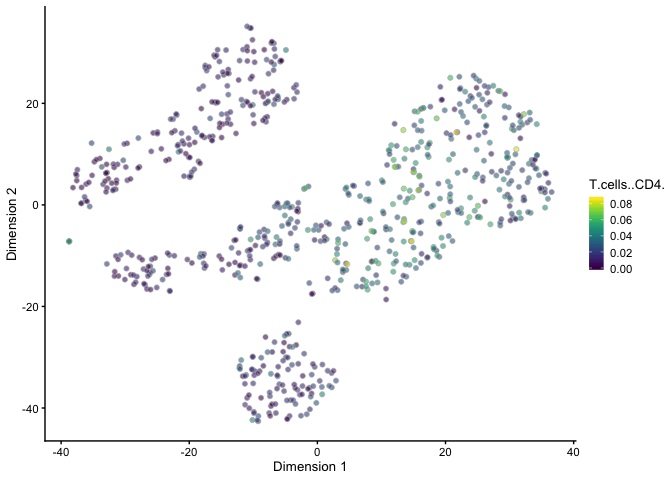

```r
plotTSNE(sce, colour_by = "T.cells..CD4.")
```

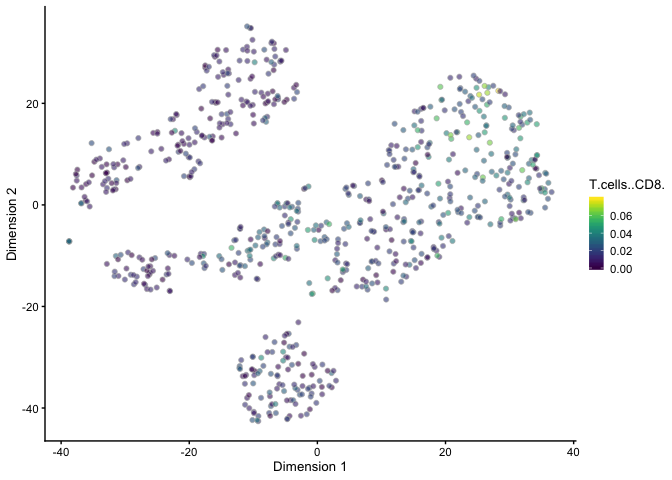

```r
plotTSNE(sce, colour_by = "T.cells..CD8.")
```

# References

Aibar, Sara, Carmen Bravo González-Blas, Thomas Moerman, Vân Anh Huynh-Thu, Hana Imrichova, Gert Hulselmans, Florian Rambow, et al. 2017. “SCENIC: Single-Cell Regulatory Network Inference and Clustering.” *Nat. Methods* 14 (11): 1083–6.

Aran, Dvir, Agnieszka P Looney, Leqian Liu, Esther Wu, Valerie Fong, Austin Hsu, Suzanna Chak, et al. 2019. “Reference-Based Analysis of Lung Single-Cell Sequencing Reveals a Transitional Profibrotic Macrophage.” *Nat. Immunol.* 20 (2): 163–72.

Zhang, Allen W, Ciara O’Flanagan, Elizabeth A Chavez, Jamie L P Lim, Nicholas Ceglia, Andrew McPherson, Matt Wiens, et al. 2019. “Probabilistic Cell-Type Assignment of Single-Cell RNA-seq for Tumor Microenvironment Profiling.” *Nat. Methods* 16 (10): 1007–15.